# (PSL) Boosting

## AdaBoost

### Toy Data

```r
set.seed(100)
x = (1:20)/10
n = length(x);
y = 2*as.numeric(runif(n) > 0.5) - 1
```

### The Algorithm

The `myboosting` function is a direct implementation of one iteration of the **AdaBoost** algorithm, customized for the toy data we’ve generated. In this dataset, the feature X is one-dimensional and ordered in ascending order: x[1] < x[2] < … x[n].

The weak classifier `g` is a simple random classifier. It randomly selects a sample point with an index between 1 to n-1 and predicts 1 for data points to the left of that selected point and -1 for data points to the right of the selected point. More formally, we can write `g` as follows: suppose the index of the sample point selected by g is m,

- g(x) = 1 if x < the midpoint between x[m] and x[m+1];
- g(x) = -1 if x >= the midpoint between x[m] and x[m+1];

```r
myboosting=function(G, w, x, y){
# G: previous committee
# w: previous weight
# x: covariates
# y: response
# g: current classifier, y=1, if x < split

 n = length(x)
 pos = sample(1:(n-1),1)
 g = c(rep(1, pos), rep(-1, n-pos))
 err = sum((1-y*g)*w)/2
 alpha = (1/2) * log((1-err)/(err))
 G = G + alpha * g
 w1 = w * exp(-alpha*y*g)
 w1 = w1 / sum(w1)
 list(G = G, w = w, w1 = w1, g = sign(alpha)*g,
      err = min(err, 1-err),
      split = (x[pos]+x[pos+1])/2, a=alpha)
}
```

The `myplot` function will be used to provide a visual illustration of AdaBoost.

```r
myplot=function(myout, x,y ){
 n=length(x); m = sum(y>0);
 tmp1=as.vector(t(matrix(c(myout$w,myout$w1), ncol=2)))
 tmp2=as.vector(t(matrix(c(x-0.04,x), ncol=2)))
 tmp3=as.vector(t(matrix(c(rep(5, n), rep(6, n)),
ncol=2)));
 mymax=max(myout$w1, myout$w);

plot(tmp2, tmp1, type="h", lwd=9, col=tmp3, xlim=c(0,2.2),
     ylim=c(-mymax/2, mymax+0.05), axes=T,
     ylab="weights", xlab="");

 points(x[y>0], rep(-mymax/6, m), pch=3)
 points(x[y<0], rep(-mymax/6, (n-m)), pch=0)

 tmp1=sum(myout$g>0);
 points(x[myout$g>0], rep(-mymax/3, tmp1), pch=3)
 points(x[myout$g<0], rep(-mymax/3, (n-tmp1)), pch=0)

 tmp1=sum(sign(myout$g[1])*sign(myout$g)==1)
 tmp2=sum((x[tmp1]+x[tmp1+1])/2)
 lines(c(tmp2, tmp2), c(-mymax/2, mymax+0.03), lty=2)

 tmp1=sum(myout$G>0);
 points(x[myout$G>0], rep(-mymax/2, tmp1), pch=3)
 points(x[myout$G<0],rep(-mymax/2, (n-tmp1)),  pch=0)

 text(2.15, -mymax/6, "data")
 text(2.15, -mymax/3, "current")
 text(2.15, -mymax/2,  "overall")
}
```

### AdaBoost in Action

**t = 1**

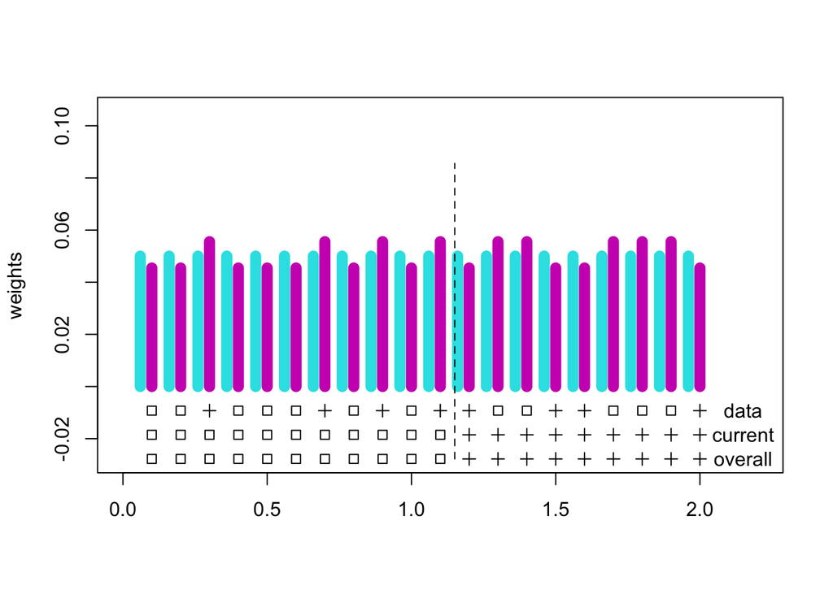

```r
G=rep(0,n); w=rep(1,n)/n;
myout=myboosting(G, w, x, y);
myplot(myout, x,y);
```

Let’s discuss the visual representation after one iteration.

- The green/blue bars represent the original weights assigned to each data point. Initially, everyone is equally weighted and has the same height.
- The purple bars represent the changes in weight over iterations. When we make mistakes in classification, the purple weights increase. This adjustment process will continue iteratively.

```r
print(paste("error of g_t = ", round(myout$err, dig=3),
            ", error of G_t = ", round(sum(sign(myout$G)!=y)/n, dig=3)))
```

```
## [1] "error of g_t =  0.45 , error of G_t =  0.45"
```

**t = 2**

```r
myout=myboosting(myout$G, myout$w1, x, y)
myplot(myout, x,y)
print(paste("error of g_t = ", round(myout$err, dig=3),
            ", error of G_t = ", round(sum(sign(myout$G)!=y)/n, dig=3)))
```

[output not shown]

**t = 3**

```r
myout=myboosting(myout$G, myout$w1, x, y)
myplot(myout, x,y)
print(paste("error of g_t = ", round(myout$err, dig=3),
            ", error of G_t = ", round(sum(sign(myout$G)!=y)/n, dig=3)))
```

[output not shown]

Below we plot the 0/1 loss and exponential loss from T=200 boosting steps.

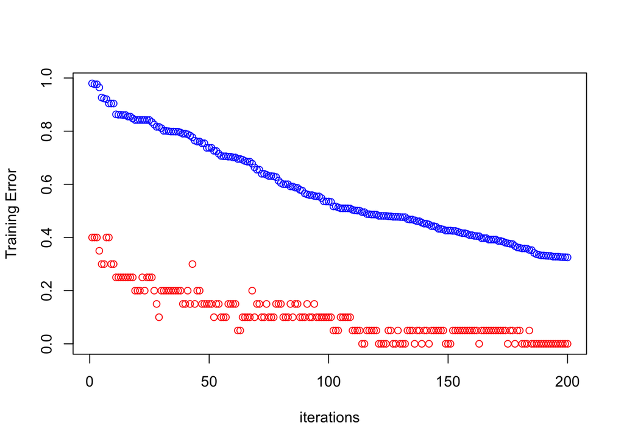

```r
T=200; err=rep(1,T); exploss=rep(0,T)
n = length(x)
G=rep(0,n); w=rep(1,n)/n
myout=myboosting(G, w, x, y)
err[1] = sum(sign(myout$G)!=y)/n
exploss[1] = sum(exp(-y*myout$G))/n

for (i in 2:T) {
    myout=myboosting(myout$G, myout$w1, x, y)
    err[i] = sum(sign(myout$G)!=y)/n
    exploss[i]=sum(exp(-y*myout$G))/n
    }

plot(c(1,T), c(0,max(err, exploss)), type="n", xlab="iterations",
     ylab="Training Error")
points(err, col="red")
points(exploss, col="blue")
```

Here’s an interesting takeaway from this illustration: the training error, represented by the red dots, does not exhibit a consistent monotonic decrease as the number of iterations (T) increases. It’s important to recall that our proof demonstrated that what decreases monotonically is not the actual training error itself but rather its upper bound, which is depicted by the blue dots.

Lastly, it’s important to note that the classifier returned by AdaBoost is not guaranteed to perform well on the test data. AdaBoost tends to overfit, so it’s essential to implement regularization or early stopping to achieve good generalization on test data.

## Early Stopping & Shrinkage

### Toy Data

The true density, denoted as p(x) = P(Y=1 | X=x), is depicted in black on the graph. The ideal classification is shown as well, with blue representing class 0 and red representing class 1. We generated a dataset of 100 training samples from this distribution.

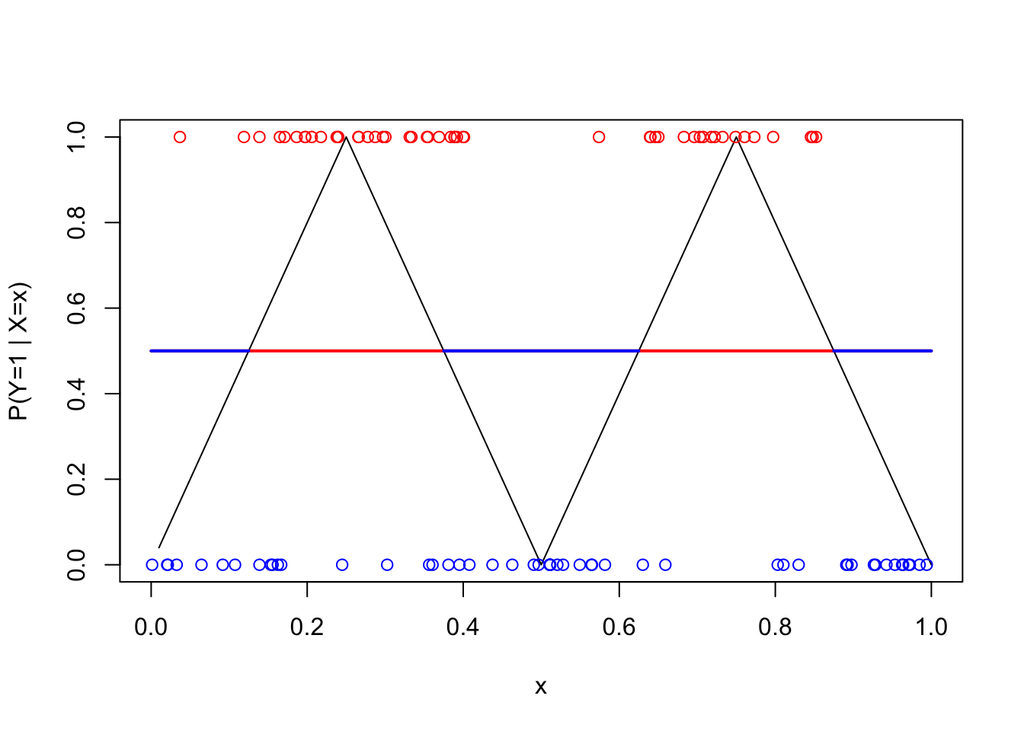

```r
d = 2
test.x = 1:100/100
dx = d * test.x - floor(d * test.x)
ptest.x = 2 * dx * as.numeric(dx <= 0.5) +
  2 * (1-dx) * as.numeric(dx > 0.5)

plot(c(0,1),c(0,1), type="n", xlab="x", ylab="P(Y=1 | X=x)")
lines(test.x, ptest.x)
lines(c(0,1), c(0.5, .5),lwd=2, col="red")
lines(c(0, 0.125), rep(0.5,2), lwd=2, col="blue")
lines(c(0.375, 0.625), rep(0.5, 2), lwd=2, col="blue")
lines(c(0.875,1), rep(0.5,2), lwd=2, col="blue")

n = 100
x = sort(runif(n))
dx = d * x - floor(d * x)
px = 2 * dx * as.numeric(dx <= 0.5) +
  2 * (1-dx) * as.numeric(dx > 0.5)
y = ifelse(px-runif(n) > 0, 1, 0)
points(x[y==1], y[y==1], col="red") ## add on sample points
points(x[y==0], y[y==0], col="blue")
```

```r
toydata = data.frame(x=x, y=y)
```

### GBM

We utilized the ‘gbm’ package with the following considerations:

- Y should be encoded as numerical values 0/1, rather than as a factor.
- Commonly used loss functions are applied, specifically ‘adaboost’ and ‘bernoulli’ for classification, ‘gaussian’ (squared error), and ‘laplace’ (absolute loss) for regression, and ‘pairwise’ for ranking.
- `n.trees`: number of trees (check the default value)
- `shrinkage`: shrinkage factor for the step size (check the default value)
- `bag.fraction`: subsampling rate (check the default value)
- `cv.folds`: return CV error (default 0, i.e., no CV error returned)
- `interaction.depth`: depth of trees (check the default value)

```r
library(gbm)
```

Additionally, we experimented with two different sets of parameters.

- In the first case, we set shrinkage = 1 (no shrinkage), highlighting the importance of early stopping to obtain a better estimate of the conditional probability P(Y=1 | X=x).
- In the second case, we reduced the shrinkage factor to 0.05 (which necessitated an increase in the number of trees). These results demonstrate that the shrinkage factor can be helpful in reducing overfitting.

The current version of the `gbm` package seems to have an issue with cross-validation (CV) when the feature X is one-dimensional. You can refer to the CV output in PDF format posted [[Here](https://liangfgithub.github.io/Rcode_W12_old_boost_CVouput.pdf)], which was generated a few years ago using an older version of the `gbm` package.

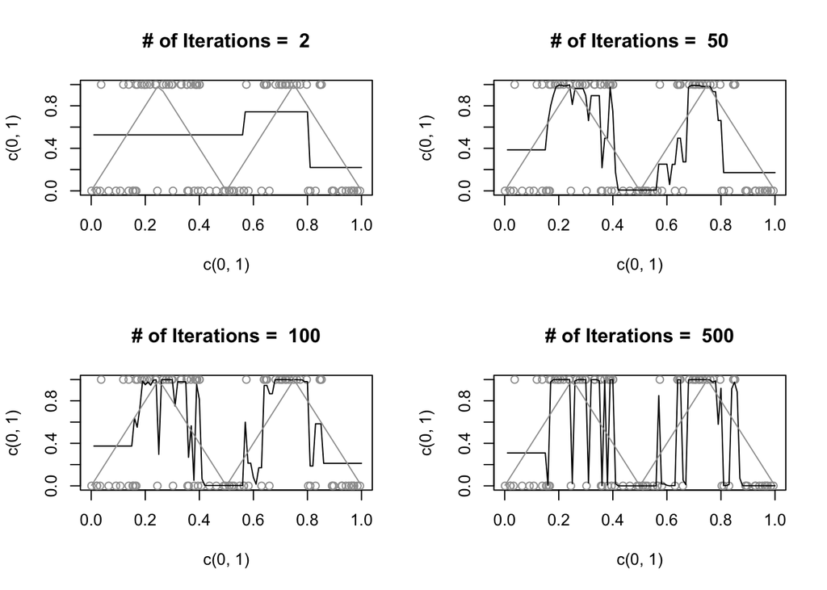

```r
toy.gbm1 = gbm(y~x, data = toydata, distribution = "adaboost",
             n.trees = 500,
             shrinkage = 1,
             bag.fraction = 0.5)

par(mfrow = c(2,2))
size=c(2,50,100,500)

for(i in 1:4){
    plot(c(0,1), c(0,1), type="n");
    points(x, as.numeric(y), col=8); ## add sample points
    y.pred = predict(toy.gbm1, data.frame(x = test.x), n.trees = size[i])
    lines(test.x, 1/(1+exp(-2*y.pred)))
    lines(x, px, col = 8)
    title(paste("# of Iterations = ", size[i]))
    }
```

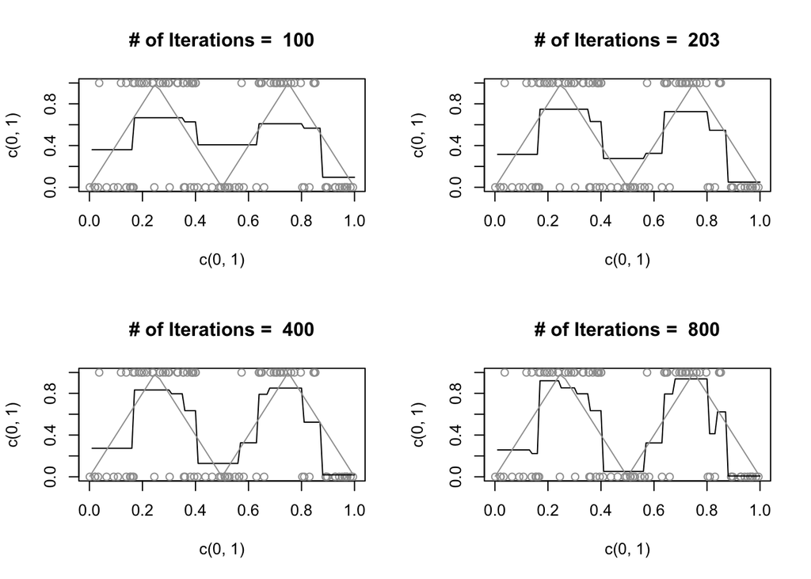

```r
toy.gbm2 = gbm(y~x, data = toydata, distribution="adaboost",
             n.trees = 1000,
             shrinkage = 0.05,
             bag.fraction = 1)

par(mfrow=c(2,2))
size=c(100,203,400,800)

for(i in 1:4){
    plot(c(0,1), c(0,1), type="n");
    points(x, as.numeric(y), col=8); ## add sample points
    y.pred = predict(toy.gbm2, data.frame(x=test.x), n.trees=size[i])
    lines(test.x, 1/(1+exp(-2*y.pred)))
    lines(x, px, col=8)
    title(paste("# of Iterations = ", size[i]))
}
```